# Calculating DraftKings fantasy points

Josh Murray

## Introduction

Today I will begin exploring play by the play by play data we scraped the other day (for the Quicken Loans National tournament) by calculating DrafKings points.

```r
# copy and save the functions from the previous post, uncomment this code and run:

# source("fetch_pbp.R")

# source("fetch_field.R")

# quick_loans <- fetch_pbp(tourn_id = "471", year = 2016)

# pbp <- quick_loans[[1]]
```

## Scoring

For those who don’t know, DraftKings is a sports betting website. You create a team of 6 golfers by drafting players from the tournament field. Each golfer costs a certain amount of money to draft, and you have a salary cap of $50,000. As per the [DraftKings website](https://www.draftkings.com/help/pga), players accumulate points as follows:

### Scoring rules

Golfers on each team will accumulate points as follows:

- Per Hole Scoring
  - Double Eagle (DBe): +20 PTs
  - Eagle (EAG): +8 PTs
  - Birdie (BIR): +3 PTs
  - Par (PAR): +0.5 PTs
  - Bogey (BOG): -0.5 PTs
  - Double Bogey (DBB): -1 PT
  - Worse than Double Bogey (DBW): -1 PT
- Tournament Finish Scoring
  - 1st: 30 PTs
  - 2nd: 20 PTs
  - 3rd: 18 PTs
  - 4th: 16 PTs
  - 5th: 14 PTs
  - 6th: 12 PTs
  - 7th: 10 PTs
  - 8th: 9 PTs
  - 9th: 8 PTs
  - 10th: 7 PTs
  - 11th–15th: 6 PTs
  - 16th–20th: 5 PTs
  - 21st–25th: 4 PTs
  - 26th–30th: 3 PTs
  - 31st–40th: 2 PTs
  - 41st-50th: 1 PTs
- Streaks and Bonuses
- Streak of 3 Birdies of Better (MAX 1 Per Round) (BIR3+): +3 PTs
- Bogey Free Round (BOFR): +3 PTs
- All 4 Rounds Under 70 Strokes (A4U70): +5 PTs
- Hole in One (ACE): +10 PTs

## Method

I will calculate points on a per round basis. I will start with calculating per-hole points, then streaks and bonuses, and finally tournament finish points. I will then add up fantasy points per round to get a total fantasy points calculation.

### Per hole scoring

Let’s begin by having a look at the data

```r
library(DT)
#number of observations and variables
dim(pbp)
```

```
## [1] 28005    27
```

```r
# number of players in the field
length(unique(pbp$player_name))
```

```
## [1] 119
```

```r
# first 5 observations
datatable(pbp[1:5,], options = list(scrollX =T))
```

|  | pid | player_name | tourn_id | tournamen_name | round_number | hole_number | round_hole_num | shot_num | putt_num | type | prv | tee_shot | cup | from | to | asc | distance | dist_left | x_loc | y_loc | z_loc | club | con | shot_text | score | par_for_day | par_for_tourn |
| --- | --- | --- | --- | --- | --- | --- | --- | --- | --- | --- | --- | --- | --- | --- | --- | --- | --- | --- | --- | --- | --- | --- | --- | --- | --- | --- | --- |
| 1 | 29745 | Tyler Aldridge | 471 | Quicken Loans National | 1 | 1 | 1 | 1 | 0 | S | n | y | n | OTB | OST | 1 | 10367 | 4309 | 11646.456 | 10503.269 | 276.995 | CDR |  | Shot 1 288 yds to fairway bunker, 120 yds to hole | 4 | 0 | 0 |
| 2 | 29745 | Tyler Aldridge | 471 | Quicken Loans National | 1 | 1 | 2 | 2 | 0 | S | n | n | n | OST | EG3 | 1 | 3466 | 845 | 11417.615 | 10679.407 | 279.901 | CUK |  | Shot 2 96 yds to right front green side bunker, 70 ft 5 in. to hole | 4 | 0 | 0 |
| 3 | 29745 | Tyler Aldridge | 471 | Quicken Loans National | 1 | 1 | 3 | 3 | 0 | S | n | n | n | OGS | OGR | 1 | 837 | 17 | 11365.137 | 10725.247 | 283.409 | CUK |  | Shot 3 69 ft 9 in. to green, 17 in. to hole | 4 | 0 | 0 |
| 4 | 29745 | Tyler Aldridge | 471 | Quicken Loans National | 1 | 1 | 4 | 4 | 1 | S | n | n | y | OGR | hole | 1 | 17 | 0 | 0 | 0 | 0 | CUK |  | Shot 4 in the hole | 4 | 0 | 0 |
| 5 | 29745 | Tyler Aldridge | 471 | Quicken Loans National | 1 | 2 | 1 | 1 | 0 | S | n | y | n | OTB | OGR | 1 | 7550 | 254 | 10678.881 | 10956.474 | 300.337 | CUK |  | Shot 1 210 yds to green, 21 ft 2 in. to hole | 2 | -1 | -1 |

To calculate per hole points we need to figure out a players score relative to par on each hole. This will tell us what type of score a player had (double eagle, eagle, birdie etc…). We have a variable that tells us the players’ score on a hole (“hole_score”), but we don’t know the par of the hole. However, we have a “par for the day” variable that keeps track of a player’s score relative to par for a given round. To calculate the score of a given hole relative to par, I will create a lag variable for the “par_for_day” variable. If a player’s par for the day increases, decreases, or stays the same on a given hole, we will know whether or not they pared the hole.

Note: the data set is a play by play recount of each player’s round. Therefore, if it took for shots for the player to “hole out” on a hole, there will be four records. We need one record for player to calculate the hole points properly. Therefore, I begin by sub-setting the data for the last shot (shot_num) for each hole.

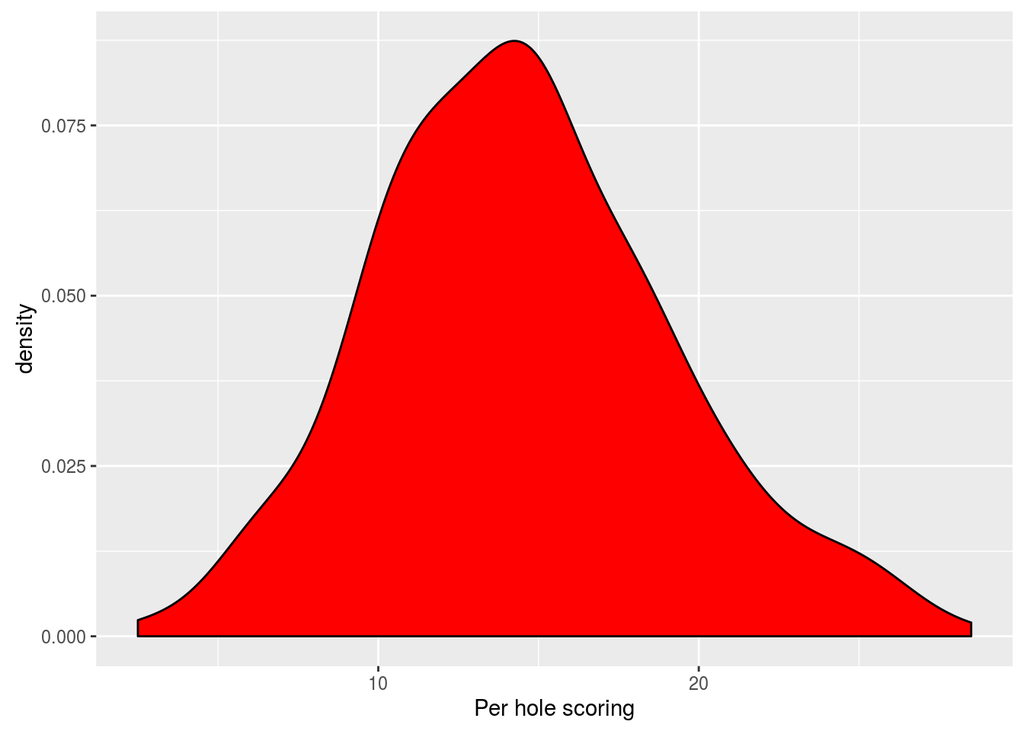

```r
library(dplyr)

# get one record per player by taking the last shot of each hole:
scores <- pbp %>% filter(shot_num == score)

scores <- scores %>% group_by(player_name, round_number) %>%
                     mutate(lag_pfd = lag(par_for_day))

# replace missing lag_par_for_day with 0
scores$lag_pfd[is.na(scores$lag_pfd)==T] <- 0

#calculate per hole points for each type of score (par, birdie, eagle, etc...)
scores$per_hole_pts <- ifelse(scores$par_for_day == (scores$lag_pfd-3), 20, # double eagle
                           ifelse(scores$par_for_day == (scores$lag_pfd-2), 8, # eagle
                              ifelse(scores$par_for_day == (scores$lag_pfd-1), 3, #birdie
                                     ifelse(scores$par_for_day == (scores$lag_pfd), .5, #par
                                            ifelse(scores$par_for_day == (scores$lag_pfd+1), -.5, #bogie
                                                   -1))))) # double bogie or worse

# add all the scores up for every round
scores <- scores %>%  group_by(player_name, round_number) %>% summarize(per_hole_pts = sum(per_hole_pts)) %>%
  ungroup()

# plot of per_hole_pts distribution
library(ggplot2)
ggplot(scores, aes(per_hole_pts)) + geom_density(fill="red") + xlab("Per hole scoring")
```

```r
# 5 number summary of per hole points
summary(scores$per_hole_pts)
```

```
##    Min. 1st Qu.  Median    Mean 3rd Qu.    Max.
##    2.50   11.00   14.50   14.53   17.50   28.50
```

### Birdie streaks or hole in one

To calculate streaks I will again subset the data to have one observation per player, per round, using the last shot taken on that hole. I will then create a dichotomous variable that takes a value of 1 if the player scored a birdie or better, and a 0 if the player got a par or worse. I will then create a function that returns a 1 if the player got a streak of 3 birdies or better in a round and a 0 otherwise. Because there is a max of one streak per round, the function returns the first streak found. I will also create a dichotomous variable that takes a value of 1 if the player got a hole in one and a 0 otherwise.

```r
streaks <- pbp %>% filter(shot_num == score)

streaks <- streaks %>% group_by(player_name, round_number) %>%
                       mutate(lag_pfd = lag(par_for_day))

# replace missing lag_par_for_day with 0
streaks$lag_pfd[is.na(streaks$lag_pfd)==T] <- 0

streaks$birdie_or_better <-ifelse(streaks$par_for_day <= (streaks$lag_pfd-1), 1, 0)


# function to return 1 if 3 birdies in a row, 0 otherwise. I put
# an argument for the streak length so that the function is flexible
calc_birdie_streaks <- function(x, k = 3) {
   n <- length(x)
   if (k > n) return(0)

   for(i in 1:(n-k+1)){
     temp <- x[i: (i+k-1)]

     if (all(temp == 1)) return(1)
   }
   return(0)
 }

streaks$hole_in_one <- ifelse(streaks$shot_num ==1, 1, 0)

streaks <- streaks %>% group_by(player_name, round_number) %>%
  summarize(birdie_streaks =calc_birdie_streaks(birdie_or_better),
            hole_in_one = sum(hole_in_one))

# how many streaks
table(streaks$birdie_streaks)
```

```
##
##   0   1
## 355  38
```

```r
# how many hole in ones
table(streaks$hole_in_one)
```

```
##
##   0
## 393
```

### Bogie free round

Players receive bonus points for completing a round without a bogie. I create a simple dichotomous variable for each hole that tells me if a player got a par or better. I then add this variable up for each player and each round. If the sum of the variable is 18 I know that the player did not get any bogies.

```r
bfr <- pbp %>% filter(shot_num == score)

bfr  <- bfr  %>% group_by(player_name, round_number) %>%
  mutate(lag_pfd = lag(par_for_day))

# replace missing lag_par_for_day with 0
bfr $lag_pfd[is.na(bfr $lag_pfd)==T] <- 0

bfr$no_bogies <-ifelse(bfr$par_for_day <= (bfr$lag_pfd), 1, 0)

bfr <- bfr %>% group_by(player_name, round_number) %>% summarize(no_bogies = sum(no_bogies)) %>% ungroup()
bfr <- bfr %>% group_by(player_name, round_number) %>% mutate(bogie_free_round = ifelse(no_bogies == 18, 1, 0))

table(bfr$bogie_free_round)
```

```
##
##   0   1
## 375  18
```

### Total scores

Here I add the scores for each player and each round. I then create a cumulative sum of each players score over the 2-4 rounds they play. I also create a “position” variable that tells me the players rank after each round. I use a long chain of ifelse statements to calculate how many additional points a player receives for their position after each round.

```r
total_scores <- pbp %>% filter(shot_num == score) %>%
                        group_by(player_name, round_number) %>%
                        summarize(round_score = sum(score)) %>%
                        group_by(player_name) %>%
                        mutate(total_score = cumsum(round_score)) %>%
                        ungroup()

total_scores <- total_scores %>% group_by(round_number) %>%
                                 mutate(position = rank(total_score, ties.method="min")) %>%
                                 arrange(desc(round_number), position) %>% ungroup()

#position points
total_scores$position_pts <- ifelse(total_scores$position == 1, 30,
                     ifelse(total_scores$position == 2, 20,
                      ifelse(total_scores$position == 3, 18,
                       ifelse(total_scores$position == 4, 16,
                        ifelse(total_scores$position == 5, 14,
                         ifelse(total_scores$position == 6, 12,
                          ifelse(total_scores$position == 7, 10,
                           ifelse(total_scores$position == 8, 9,
                            ifelse(total_scores$position == 9, 8,
                             ifelse(total_scores$position == 10, 7,
                              ifelse(total_scores$position >10 & total_scores$position <= 15, 6,
                               ifelse(total_scores$position >15 & total_scores$position <= 20, 5,
                                ifelse(total_scores$position >20 & total_scores$position <= 25, 4,
                                 ifelse(total_scores$position >25 & total_scores$position <= 30, 3,
                                  ifelse(total_scores$position >30 & total_scores$position <= 40, 2,
                                   ifelse(total_scores$position >40 & total_scores$position <= 50, 1, 0))))))))))))))))
head(total_scores)
```

```
## Source: local data frame [6 x 6]
##
##        player_name round_number round_score total_score position
##              (chr)        (int)       (dbl)       (dbl)    (int)
## 1         Jon Rahm            1          64          64        1
## 2  Jhonattan Vegas            1          65          65        2
## 3        Bill Haas            1          66          66        3
## 4 Billy Hurley III            1          66          66        3
## 5  Camilo Villegas            1          66          66        3
## 6        Ernie Els            1          66          66        3
## Variables not shown: position_pts (dbl)
```

### 4 rounds under 70

```r
under70 <- pbp %>% filter(shot_num == score, round_number <=4) %>%
                   group_by(player_name, round_number) %>%
                   summarize(round_score = sum(score), under_70 = round_score < 70) %>%
                   group_by(player_name) %>%
                   summarize(sum_under70 = sum(under_70),
                             all_under_70 = ifelse(sum_under70==4, 1, 0))

# number of players with all 4 rounds in the 60's
table(under70$all_under_70)
```

```
##
##   0   1
## 117   2
```

## Putting it all together

To calculate the per round fantasy points I merge the total scores data set with the birdie streaks/hole in one data set, the points per hole data set, and the bogie free round data set. I then create a DraftKings fantasy points variable (“dkfp”) but adding up the points according to the scoring rules above. Below I also plot the trajectories of points for each player over the course of the tournament.

```r
library(plotly)
# per round DraftKings points
per_round_dkfp <- total_scores %>% left_join(streaks) %>% left_join(scores) %>% left_join(bfr)
# calculate draft_kings_fantasy_points
per_round_dkfp$dkfp <- per_round_dkfp$position_pts + (per_round_dkfp$birdie_streaks*3) +
                           (per_round_dkfp$hole_in_one*10) + per_round_dkfp$per_hole_pts +
                           (per_round_dkfp$bogie_free_round*3)

# summary statistics
summary_dkfp <- per_round_dkfp %>% group_by(round_number) %>% summarize(mean_dkfp = mean(dkfp),
                                                                   sd_dkfp = sd(dkfp),
                                                                   p_10 = quantile(dkfp, .1),
                                                                   p_90 = quantile(dkfp, .9))

summary_dkfp
```

```
## Source: local data frame [4 x 5]
##
##   round_number mean_dkfp   sd_dkfp  p_10  p_90
##          (int)     (dbl)     (dbl) (dbl) (dbl)
## 1            1  19.18067 10.137138   9.5 30.90
## 2            2  16.79661  8.210957   8.5 26.65
## 3            3  18.11538  9.384957   9.2 30.00
## 4            4  18.66026  8.782913  10.0 30.65
```

```r
p <-ggplot(per_round_dkfp, aes(x = round_number, y = dkfp, group =player_name))+
    geom_line(aes(text =player_name)) + xlab("Round number") + ylab("DraftKings fantasy points")

ggplotly(p)
```

[interactive chart not shown]

Now I calculate total DraftKings points for each player. To do this I add the points ignoring the points given for finishing position. I then merge the data set created to calculate number of rounds under 70, and the finishing position at the end of the tournament. I then created a total_dkfp variable as per the rules above and plot the distribution of points.

```r
total_dkfp <- total_scores %>% left_join(streaks) %>% left_join(scores) %>% left_join(bfr)
```

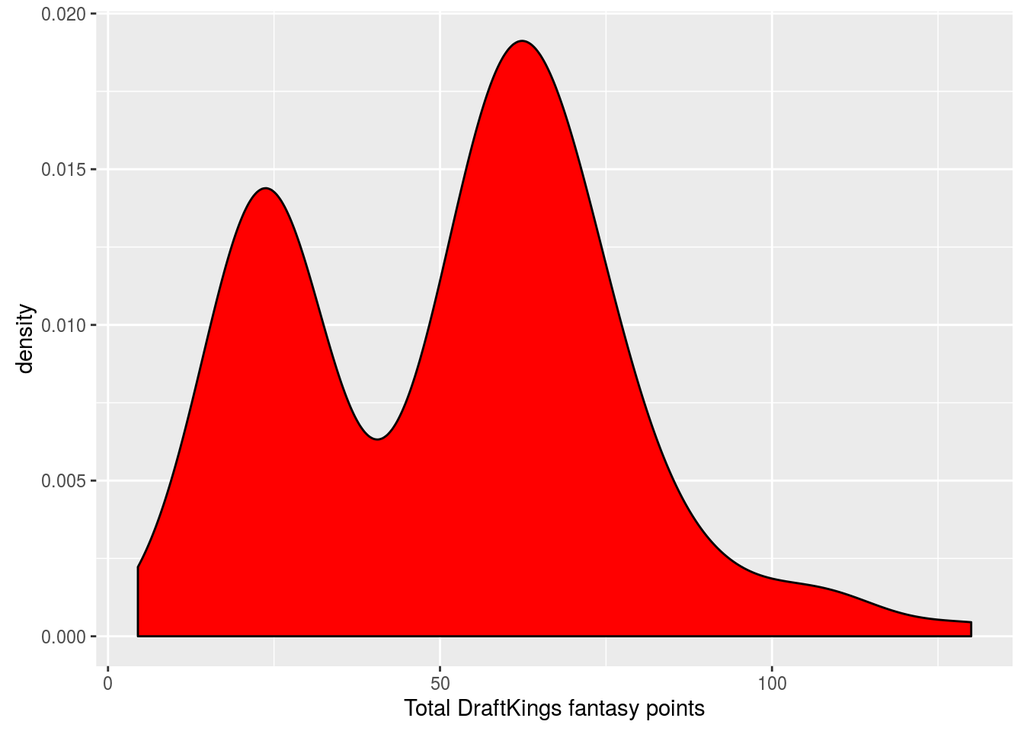

```r
total_dkfp$dkfp <- (total_dkfp$birdie_streaks*3) + (total_dkfp$hole_in_one*10) +
                  total_dkfp$per_hole_pts + (total_dkfp$bogie_free_round*3)

total_dkfp <- total_dkfp %>% group_by(player_name) %>%  summarize(total_dkfp = sum(dkfp)) %>%
  ungroup()

round4 <- total_scores %>% filter(round_number == 4)

total_dkfp <- total_dkfp %>% left_join(round4, by = ("player_name")) %>% left_join(under70, by = ("player_name"))

total_dkfp$position_pts[is.na(total_dkfp$position_pts)==T] <- 0

total_dkfp <- total_dkfp %>%  mutate(total_dkfp =total_dkfp + position_pts + (all_under_70*5)) %>%
                              select(player_name, total_dkfp)

ggplot(total_dkfp, aes(total_dkfp))+ geom_density(fill="red") + xlab("Total DraftKings fantasy points")
```

All of the above work could be packaged in a function to make fantasy point calculation easy for any tournament. It might be useful to create a cumulative fantasy point variable as opposed to a per round fantasy point variable.

## Basic exploration

For a very basic exploration of the data, let’s look at the shape of the relationship between scores and fantasy points per round looks like.

```r
p <- per_round_dkfp %>% filter(round_score > 50) %>%
  ggplot(aes(x = round_score, y = dkfp)) + geom_jitter() + geom_smooth()
ggplotly(p)
```

[interactive chart not shown]

There’s quite a bit of variation around some of these scores. I see, for example, three players that scored a 72 in a round with dkfp < 10 and another player with a score of 72 and dkfp > 30. We can see why below.

```r
per_round_dkfp %>% filter(round_score ==72, dkfp <10 | dkfp >30) %>% select(player_name, round_number,
                                                                            round_score, per_hole_pts,
                                                                            position_pts, dkfp)
```

```
## Source: local data frame [4 x 6]
##
##    player_name round_number round_score per_hole_pts position_pts  dkfp
##          (chr)        (int)       (dbl)        (dbl)        (dbl) (dbl)
## 1    Ben Crane            1          72          8.0            0   8.0
## 2 Chad Collins            1          72          9.5            0   9.5
## 3     John Huh            1          72          9.5            0   9.5
## 4    Ernie Els            4          72         17.5           14  31.5
```

Ernie Els had 14 extra points for finishing in 5th place. He also had additional points for having more birdies than the other players. There is more variation near the top of the dkfp distribution due to the large amount of extra points given for better finishing positions. Let’s remove points received for finishing position and look at the relationship again.

```r
# calculate draft_kings_fantasy_points
per_round_dkfp$dkfp <- (per_round_dkfp$birdie_streaks*3) +
                           (per_round_dkfp$hole_in_one*10) + per_round_dkfp$per_hole_pts +
                           (per_round_dkfp$bogie_free_round*3)

p <- per_round_dkfp %>% filter(round_score > 50) %>%
  ggplot(aes(x = round_score, y = dkfp)) + geom_jitter() + geom_smooth()
ggplotly(p)
```

[interactive chart not shown]

The relationship is more linear and a lot of the variation has been removed near the top of the distribution.

## Future posts

In a future post I will look at predicting dkfp using performance in previous tournaments.